# DC Peanut butter synthetic control

Install packages and load library.

```r
#install.packages('tidyverse')
#install.packages("Synth")
library(tidyverse)
library(lubridate)
library(Synth)
```

Unzip the ‘peanutbutter.tgz’ file. Read in 2011 movement and store files, merge them based on the store code, and filter for ‘F’ (food stores) and states North Dakota, Minnesota, Missouri, and D.C.

```r
untar("peanutbutter.tgz")

move_11 <- read_tsv("nielsen_extracts/RMS/2011/Movement_Files/0506_2011/1421_2011.tsv")
stores_11 <- read_tsv("nielsen_extracts/RMS/2011/Annual_Files/stores_2011.tsv")
full_11 <- move_11 %>%
  inner_join(stores_11, by ="store_code_uc") %>%
  filter(channel_code == "F",
         fips_state_descr %in% c("ND", "MN", "MO" ,"DC"))

save(full_11, file = 'pb_full_11.RData')

rm(move_11, stores_11, full_11)
```

Perform the previous step for 2012 and 2013.

```r
move_12 <- read_tsv("nielsen_extracts/RMS/2012/Movement_Files/0506_2012/1421_2012.tsv")
stores_12 <- read_tsv("nielsen_extracts/RMS/2012/Annual_Files/stores_2012.tsv")
full_12 <- move_12 %>%
  inner_join(stores_12, by ="store_code_uc") %>%
  filter(channel_code == "F",
         fips_state_descr %in% c("ND", "MN", "MO" ,"DC"))

save(full_12, file = 'pb_full_12.RData')

rm(move_12, stores_12, full_12)

move_13 <- read_tsv("nielsen_extracts/RMS/2013/Movement_Files/0506_2013/1421_2013.tsv")
stores_13 <- read_tsv("nielsen_extracts/RMS/2013/Annual_Files/stores_2013.tsv",
                      col_types = list(col_double(), col_double(),
                      col_double(), col_double(), col_character(),
                      col_character(), col_double(), col_character(),
                      col_double(), col_character(), col_double(), col_character()))

full_13 <- move_13 %>%
  inner_join(stores_13, by = "store_code_uc") %>%
  filter(channel_code == "F",
         fips_state_descr %in% c("ND", "MN", "MO", "DC"))

save(full_13, file = 'pb_full_13.RData')

rm(move_13, stores_13)
```

Bind full_11,12,13 into one tbl, ‘full_11_12_13’. Overwrite the variable week_end to be in year-month-date format. Create sales variable, which is the number of units sold multiplied by the price.

```r
load('pb_full_11.RData')
load('pb_full_12.RData')

full_11_12_13 <- full_11 %>%
  bind_rows(full_12) %>%
  bind_rows(full_13) %>%
  mutate(week_end = ymd(week_end), sales = units * price)

rm(full_11, full_12, full_13)
```

Read in products master file.

```r
products <- read_tsv('products.tsv', quote = "")
```

Merge products file and full_11_12_13.

```r
full_11_12_13 <- full_11_12_13 %>%
  left_join(products, by = 'upc')

rm(products)
```

```r
dc_data <- full_11_12_13 %>%
  filter(fips_state_descr == 'DC')

treated_stores <- dc_data %>% filter(retailer_code==842) %>% distinct(store_code_uc)

control_stores <- dc_data %>% filter(retailer_code!=842) %>% distinct(store_code_uc)
```

Assign munfacturer for each brand. Organize data by stores and date, add sales across UPCs.

```r
dc_data <- dc_data %>%
  mutate(manuf_name = substr(dc_data$brand_descr, 1, 3)) %>%
  filter(manuf_name %in% c('SKI', "JIF", "SMU", "SIM", "SAN", "ADA", "CTL")) %>%
  mutate(actual_manuf = if_else(manuf_name == 'CTL', 'CTL',
                        if_else(manuf_name == 'SKI', 'UNI', 'SMU'))) %>%
  mutate(store_code_uc=as.numeric(store_code_uc))

dc_data <- dc_data %>% group_by(store_code_uc, week_end) %>% summarize(sales=sum(sales)) %>%
  arrange(store_code_uc, week_end)

dc_data <- as.data.frame(dc_data)
```

Check store codes to see how many weeks they have. Stores with less than 157 weeks of observations are dropped from the data. Then we arrange by ‘store_code_uc’ and ‘week_end’, then create a ‘n_week_end’ variable to represent the date numerically.

```r
weeks <- unique(dc_data$week_end)

codes <- unique(dc_data$store_code_uc)

drops <- c()

for (i in seq_along(codes)) {

  single_store <- dc_data %>% filter(store_code_uc==codes[i])

  single_store_vec <- unique(single_store$week_end)

  if (length(single_store_vec) < length(weeks)) {

    drops <- c(drops, codes[i])

  }

}

dc_data <- dc_data %>% filter(!store_code_uc %in% drops) %>% arrange(store_code_uc, week_end) %>%
  mutate(n_week_end=as.numeric(week_end))

control_stores <- control_stores %>% filter(!store_code_uc %in% drops)
```

Use data prep to create weights for synthetic control.

```r
dataprep_out <- dataprep(foo=dc_data, predictors="sales", dependent="sales", unit.variable="store_code_uc",
                         time.variable="n_week_end", treatment.identifier=5133302,
                         controls.identifier=control_stores$store_code_uc,
                         time.predictors.prior=seq(14975, 15535, by = 7), time.optimize.ssr=seq(14975, 15535, by = 7),
                         time.plot=seq(14975, 16067, by = 7))

synth_out <- synth(dataprep_out)
```

```
##
## X1, X0, Z1, Z0 all come directly from dataprep object.
##
##
## ****************
##  optimization over w weights: computing synthtic control unit
##
##
##
## ****************
## ****************
## ****************
##
## MSPE (LOSS V): 24014.56
##
## solution.v:
##  1
##
## solution.w:
##  0.03670724 0.03469845 0.02984143 0.01159974 0.4612645 0.03238041 0.03246352 0.03670635 0.03585614 0.03173574 0.036639 0.02044926 0.02551085 0.03672516 0.03472481 0.03640007 0.0367203 0.02957704
```

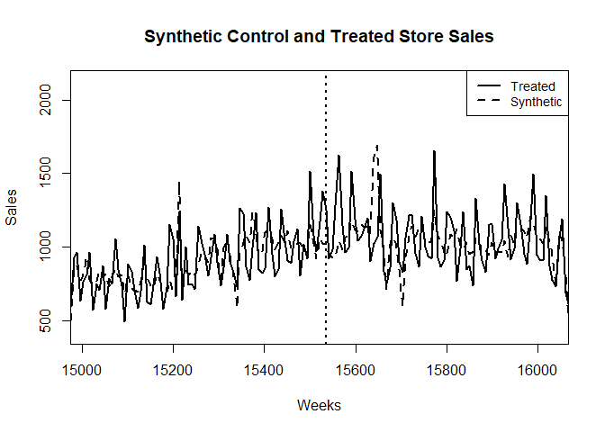

```r
path.plot(dataprep.res = dataprep_out, synth.res = synth_out, Xlab = c('Weeks'), Ylab = c('Sales'), tr.intake = 15535,
          Main = 'Synthetic Control and Treated Store Sales')
```

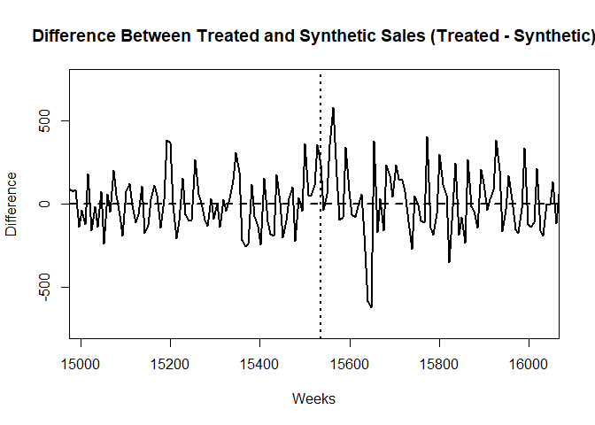

```r
gaps.plot(dataprep.res = dataprep_out, synth.res = synth_out, Ylab = 'Difference', Xlab = 'Weeks', tr.intake = 15535,
          Main = 'Difference Between Treated and Synthetic Sales (Treated - Synthetic)')
```

```r
synth_tables <- synth.tab(synth.res = synth_out, dataprep.res = dataprep_out)
synth_tables$tab.w
```

```
##         w.weights unit.names unit.numbers
## 1804471     0.037    1804471      1804471
## 3949012     0.035    3949012      3949012
## 5148299     0.030    5148299      5148299
## 1802456     0.012    1802456      1802456
## 2078770     0.461    2078770      2078770
## 1808501     0.032    1808501      1808501
## 1028103     0.032    1028103      1028103
## 5319048     0.037    5319048      5319048
## 2319813     0.036    2319813      2319813
## 3521655     0.032    3521655      3521655
## 5524392     0.037    5524392      5524392
## 1860488     0.020    1860488      1860488
## 1657215     0.026    1657215      1657215
## 1788754     0.037    1788754      1788754
## 1807292     0.035    1807292      1807292
## 7962112     0.036    7962112      7962112
## 5164822     0.037    5164822      5164822
## 1809307     0.030    1809307      1809307
```

```r
synth_tables$tab.pred
```

```
##       Treated Synthetic Sample Mean
## sales 897.081   897.082     1243.61
```

```r
dataprep_out$Y1plot
```

```
##       5133302
## 14975  588.81
## 14982  926.88
## 14989  965.48
## 14996  634.20
## 15003  764.45
## 15010  812.04
## 15017  963.42
## 15024  574.88
## 15031  749.78
## 15038  706.55
## 15045  871.62
## 15052  577.97
## 15059  789.88
## 15066  750.94
```

[output cut: 143 more lines]